# Shark_Tank_US_Prediction_Code

Now we consider 4 classification models for predicting which sharks are gonna invest. These models are RandomForestClassifier, LogisticRegression, SVM and XGBClassifier. These four models were chosen to cover a range of strengths and approaches for classification. Random Forest is robust, captures non-linear relationships, and helps understand feature importance. Logistic Regression provides a simple, interpretable baseline for comparison. SVM is effective for non-linear decision boundaries and works well with standardized data. XGBoost, a powerful gradient-boosting model, excels at capturing complex patterns and is widely used for its performance. This mix ensures a balanced evaluation of different algorithms for predicting shark investments.

```python
df_regres = df.copy()
y = np.array([np.array(x) for x in df['Sharks Invested']])
X = df.drop(columns=['Sharks Invested', 'Sharks Investment Amounts'])
scaler = StandardScaler()
X = scaler.fit_transform(X)
```

```python
X_train, X_temp, y_train, y_temp = train_test_split(X, y, test_size=0.3, random_state=42)
X_valid, X_test, y_valid, y_test = train_test_split(X_temp, y_temp, test_size=0.5, random_state=42)
```

How SMOTE Works:

Identify Minority Class Instances: SMOTE first identifies the instances that belong to the minority class.

Find Nearest Neighbors: For each minority-class instance, SMOTE finds a specified number of its closest neighbors within the minority class.

Generate Synthetic Samples: Instead of merely duplicating minority samples, SMOTE creates new, synthetic examples by interpolating between the selected instance and its neighbors. Essentially, it picks a point between the two existing samples to form a new, more diverse example of the minority class.

```python
def apply_smote(X_train, y_shark, random_state=42):
    unique = np.unique(y_shark)
    if len(unique) > 1:
        smote = SMOTE(random_state=random_state)
        X_train_balanced, y_train_balanced = smote.fit_resample(X_train, y_shark)
        print("Applied SMOTE balancing")
    else:
        X_train_balanced, y_train_balanced = X_train, y_shark
        print("Skipping SMOTE - only one class present")
    return X_train_balanced, y_train_balanced
```

```python
from sklearn.model_selection import GridSearchCV
from sklearn.metrics import accuracy_score, classification_report

def tune_hyperparameters(X_train, X_valid, y_train, y_valid, models, param_grids):
    tuned_models = {}
    for model_name, model in models.items():
        print(f"\nTuning {model_name}")
        grid_search = GridSearchCV(
            estimator=model,
            param_grid=param_grids[model_name],
            cv=5,
            scoring='accuracy',
            n_jobs=-1
        )

        grid_search.fit(X_train, y_train)
        best_model = grid_search.best_estimator_
        best_params = grid_search.best_params_

        valid_pred = best_model.predict(X_valid)
        valid_acc = accuracy_score(y_valid, valid_pred)

        print(f"Best Parameters for {model_name}:")
        for param, value in best_params.items():
            print(f"{param}: {value}")
        print(f"Best Validation Accuracy: {valid_acc:.4f}")

        tuned_models[model_name] = {
            'model': best_model,
            'params': best_params,
            'accuracy': valid_acc
        }

    return tuned_models

models = {
    'Random Forest': RandomForestClassifier(random_state=23),
    'Logistic Regression': LogisticRegression(max_iter=1000, random_state=23),
    'XGBoost': XGBClassifier(
        random_state=23,
        use_label_encoder=False,
        eval_metric='logloss'
    )
}

param_grids = {
    'Random Forest': {
        'n_estimators': [50, 60, 80, 100],
        'max_depth': [2, 5, 10, None]
    },
    'Logistic Regression': {
        'C': [0.001, 0.01, 0.1, 1, 10, 100],
        'penalty': ['l1', 'l2'],
        'solver': ['liblinear', 'saga']
    },
    'XGBoost': {
        'n_estimators': [50, 70, 80, 100],
        'max_depth': [3, 6, 9],
        'learning_rate': [0.001, 0.0001, 0.01, 0.1]
    }
}

for shark_idx in range(y_train.shape[1]):
    print(f"\n--- Hyperparameter Tuning for Shark {shark_idx + 1} ---")
    X_train_balanced, y_train_balanced = apply_smote(X_train, y_train[:, shark_idx])
    tuned_models = tune_hyperparameters(
        X_train_balanced, X_valid,
        y_train_balanced, y_valid[:, shark_idx],
        models, param_grids
    )
    best_model_name = max(tuned_models, key=lambda x: tuned_models[x]['accuracy'])
    print(f"\nBest Model for Shark {shark_idx + 1}: {best_model_name}")
```

```
--- Hyperparameter Tuning for Shark 1 ---
Applied SMOTE balancing

Tuning Random Forest
Best Parameters for Random Forest:
max_depth: None
n_estimators: 100
Best Validation Accuracy: 0.8439

Tuning Logistic Regression
Best Parameters for Logistic Regression:
C: 0.1
penalty: l1
solver: liblinear
Best Validation Accuracy: 0.6000

Tuning XGBoost
Best Parameters for XGBoost:
learning_rate: 0.1
max_depth: 9
n_estimators: 70
Best Validation Accuracy: 0.9073

Best Model for Shark 1: XGBoost

--- Hyperparameter Tuning for Shark 2 ---
Applied SMOTE balancing

Tuning Random Forest
Best Parameters for Random Forest:
max_depth: None
n_estimators: 100
Best Validation Accuracy: 0.7171

Tuning Logistic Regression
Best Parameters for Logistic Regression:
C: 0.01
penalty: l2
solver: saga
Best Validation Accuracy: 0.4878

Tuning XGBoost
Best Parameters for XGBoost:
learning_rate: 0.1
max_depth: 6
n_estimators: 80
Best Validation Accuracy: 0.7317

Best Model for Shark 2: XGBoost

--- Hyperparameter Tuning for Shark 3 ---
Applied SMOTE balancing

Tuning Random Forest
Best Parameters for Random Forest:
max_depth: None
n_estimators: 50
Best Validation Accuracy: 0.7220

Tuning Logistic Regression
Best Parameters for Logistic Regression:
C: 0.1
penalty: l2
solver: liblinear
Best Validation Accuracy: 0.4000

Tuning XGBoost
Best Parameters for XGBoost:
learning_rate: 0.1
max_depth: 9
n_estimators: 100
Best Validation Accuracy: 0.7659

Best Model for Shark 3: XGBoost

--- Hyperparameter Tuning for Shark 4 ---
Applied SMOTE balancing

Tuning Random Forest
Best Parameters for Random Forest:
max_depth: None
n_estimators: 50
Best Validation Accuracy: 0.8439

Tuning Logistic Regression
Best Parameters for Logistic Regression:
C: 100
penalty: l1
solver: liblinear
Best Validation Accuracy: 0.6488

Tuning XGBoost
Best Parameters for XGBoost:
learning_rate: 0.1
max_depth: 9
n_estimators: 100
Best Validation Accuracy: 0.8683

Best Model for Shark 4: XGBoost

--- Hyperparameter Tuning for Shark 5 ---
Applied SMOTE balancing

Tuning Random Forest
Best Parameters for Random Forest:
max_depth: None
n_estimators: 60
Best Validation Accuracy: 0.8683

Tuning Logistic Regression
Best Parameters for Logistic Regression:
C: 0.01
penalty: l2
solver: liblinear
Best Validation Accuracy: 0.6585

Tuning XGBoost
Best Parameters for XGBoost:
learning_rate: 0.1
max_depth: 9
n_estimators: 100
Best Validation Accuracy: 0.8390

Best Model for Shark 5: Random Forest

--- Hyperparameter Tuning for Shark 6 ---
Applied SMOTE balancing

Tuning Random Forest
Best Parameters for Random Forest:
max_depth: None
n_estimators: 100
Best Validation Accuracy: 0.8000

Tuning Logistic Regression
Best Parameters for Logistic Regression:
C: 100
penalty: l2
solver: liblinear
Best Validation Accuracy: 0.5659

Tuning XGBoost
Best Parameters for XGBoost:
learning_rate: 0.1
max_depth: 9
n_estimators: 100
Best Validation Accuracy: 0.8341

Best Model for Shark 6: XGBoost
```

```python
models = {
    'Random Forest': RandomForestClassifier(n_estimators=100, max_depth=None, random_state=23),
    'Logistic Regression': LogisticRegression(
        C=0.1,
        penalty='l2',
        solver='liblinear',
        max_iter=1000,
        random_state=23
    ),
    'SVM': SVC(kernel='rbf', random_state=23),
    'XGBoost': XGBClassifier(
        n_estimators=100,
        max_depth=9,
        learning_rate=0.1,
        random_state=23,
        use_label_encoder=False,
        eval_metric='logloss'
    )
}
```

```python
def analyze_results(results, shark_idx):
    best_model_name = max(
        results.items(),
        key=lambda x: x[1]['test_acc']
    )[0]
    print(f"\nBest Model for Shark {shark_idx + 1}: {best_model_name}")
    print(f"Test Accuracy: {results[best_model_name]['test_acc']:.4f}")

    return best_model_name
```

```python
def print_detailed_metrics(X_train, X_test, y_train, y_test, shark_idx,
                         best_model_name, models):
    y_shark = y_train[:, shark_idx]
    X_train_balanced, y_train_balanced = apply_smote(X_train, y_shark)
    models[best_model_name].fit(X_train_balanced, y_train_balanced)
    y_pred = models[best_model_name].predict(X_test)
    print("\nConfusion Matrix:")
    cm = confusion_matrix(y_test[:, shark_idx], y_pred)
    print(cm)
    print("\nClassification Report:")
    print(classification_report(y_test[:, shark_idx], y_pred))
```

```python
import os
import pickle
if not os.path.exists('saved_models_cls'):
    os.makedirs('saved_models_cls')
with open('saved_models_cls/scaler.pkl', 'wb') as f:
    pickle.dump(scaler, f)
```

```python
def train_and_evaluate_shark(X_train, X_valid, X_test, y_train, y_valid, y_test,
                           shark_idx, models):
    results = {model_name: {'valid_acc': [], 'test_acc': []}
              for model_name in models.keys()}

    y_shark = y_train[:, shark_idx]

    unique, counts = np.unique(y_shark, return_counts=True)
    print(f"Original distribution: {dict(zip(unique, counts))}")

    X_train_balanced, y_train_balanced = apply_smote(X_train, y_shark)

    unique, counts = np.unique(y_train_balanced, return_counts=True)
    print(f"Final distribution: {dict(zip(unique, counts))}")

    for model_name, model in models.items():
        print(f"\nTraining {model_name} for Shark {shark_idx + 1}")

        model.fit(X_train_balanced, y_train_balanced)

        valid_pred = model.predict(X_valid)
        test_pred = model.predict(X_test)

        valid_acc = accuracy_score(y_valid[:, shark_idx], valid_pred)
        test_acc = accuracy_score(y_test[:, shark_idx], test_pred)
        results[model_name]['valid_acc'] = valid_acc
        results[model_name]['test_acc'] = test_acc

        print(f"{model_name} - Validation Accuracy: {valid_acc:.4f}, "
              f"Test Accuracy: {test_acc:.4f}")

    return results
```

```python
import matplotlib.pyplot as plt
import seaborn as sns
from sklearn.metrics import roc_curve, auc, confusion_matrix
import numpy as np

def plot_all_results(results, shark_idx, X_test, y_test, models, best_model_name):
    fig = plt.figure(figsize=(20, 6))
    gs = fig.add_gridspec(1, 3)
    ax1 = fig.add_subplot(gs[0, 0])
    models_list = list(results.keys())
    valid_acc = [results[model]['valid_acc'] for model in models_list]
    test_acc = [results[model]['test_acc'] for model in models_list]
    x = np.arange(len(models_list))
    width = 0.35

    ax1.bar(x - width/2, valid_acc, width, label='Validation Accuracy', color='skyblue')
    ax1.bar(x + width/2, test_acc, width, label='Test Accuracy', color='lightgreen')
    ax1.set_ylabel('Accuracy')
    ax1.set_title(f'Model Performance Comparison\nShark {shark_idx + 1}')
    ax1.set_xticks(x)
    ax1.set_xticklabels(models_list, rotation=45)
    ax1.legend()
    ax2 = fig.add_subplot(gs[0, 1])
    best_model = models[best_model_name]
    y_pred = best_model.predict(X_test)
    cm = confusion_matrix(y_test[:, shark_idx], y_pred)

    sns.heatmap(cm, annot=True, fmt='d', cmap='Blues',
                xticklabels=['No Investment', 'Investment'],
                yticklabels=['No Investment', 'Investment'],
                ax=ax2)
    ax2.set_title(f'Confusion Matrix - {best_model_name}\nShark {shark_idx + 1}')
    ax2.set_ylabel('True Label')
    ax2.set_xlabel('Predicted Label')
    ax3 = fig.add_subplot(gs[0, 2])

    for model_name, model in models.items():
        if hasattr(model, 'predict_proba'):
            y_score = model.predict_proba(X_test)[:, 1]
        else:
            y_score = model.decision_function(X_test)

        fpr, tpr, _ = roc_curve(y_test[:, shark_idx], y_score)
        roc_auc = auc(fpr, tpr)

        ax3.plot(fpr, tpr, label=f'{model_name} (AUC = {roc_auc:.2f})')

    ax3.plot([0, 1], [0, 1], 'k--')
    ax3.set_xlim([0.0, 1.0])
    ax3.set_ylim([0.0, 1.05])
    ax3.set_xlabel('False Positive Rate')
    ax3.set_ylabel('True Positive Rate')
    ax3.set_title(f'ROC Curves\nShark {shark_idx + 1}')
    ax3.legend(loc="lower right")

    plt.tight_layout()
    return fig
```

```python
all_results = []
for shark_idx in range(y_train.shape[1]):
    print(f"\nProcessing Shark {shark_idx + 1}")
    results = train_and_evaluate_shark(
        X_train, X_valid, X_test, y_train, y_valid, y_test, shark_idx, models
    )
    best_model_name = analyze_results(results, shark_idx)
    print_detailed_metrics(
        X_train, X_test, y_train, y_test, shark_idx, best_model_name, models
    )
    fig = plot_all_results(results, shark_idx, X_test, y_test, models, best_model_name)
    plt.savefig(f'shark_{shark_idx+1}_results.png', dpi=300, bbox_inches='tight')
    plt.close()
    best_model = models[best_model_name]
    with open(f'saved_models_cls/shark_{shark_idx+1}_model.pkl', 'wb') as f:
        pickle.dump(best_model, f)

    all_results.append({
        'shark_idx': shark_idx,
        'best_model': best_model_name,
        'results': results
    })
plt.figure(figsize=(12, 6))
shark_names = [f"Shark {i+1}" for i in range(len(all_results))]
best_accuracies = [result['results'][result['best_model']]['test_acc']
                   for result in all_results]
best_models = [result['best_model'] for result in all_results]
```

```
Processing Shark 1
Original distribution: {0: 861, 1: 94}
Applied SMOTE balancing
Final distribution: {0: 861, 1: 861}

Training Random Forest for Shark 1
Random Forest - Validation Accuracy: 0.8049, Test Accuracy: 0.7902

Training Logistic Regression for Shark 1
Logistic Regression - Validation Accuracy: 0.6195, Test Accuracy: 0.6244

Training SVM for Shark 1
SVM - Validation Accuracy: 0.6683, Test Accuracy: 0.6634

Training XGBoost for Shark 1
XGBoost - Validation Accuracy: 0.7463, Test Accuracy: 0.7512

Best Model for Shark 1: Random Forest
Test Accuracy: 0.7902
Applied SMOTE balancing

Confusion Matrix:
[[154  27]
 [ 16   8]]

Classification Report:
              precision    recall  f1-score   support

           0       0.91      0.85      0.88       181
           1       0.23      0.33      0.27        24

    accuracy                           0.79       205
   macro avg       0.57      0.59      0.57       205
weighted avg       0.83      0.79      0.81       205


Processing Shark 2
Original distribution: {0: 779, 1: 176}
Applied SMOTE balancing
Final distribution: {0: 779, 1: 779}

Training Random Forest for Shark 2
Random Forest - Validation Accuracy: 0.6732, Test Accuracy: 0.6683

Training Logistic Regression for Shark 2
Logistic Regression - Validation Accuracy: 0.4976, Test Accuracy: 0.5122

Training SVM for Shark 2
SVM - Validation Accuracy: 0.5415, Test Accuracy: 0.5268

Training XGBoost for Shark 2
XGBoost - Validation Accuracy: 0.6049, Test Accuracy: 0.6244

Best Model for Shark 2: Random Forest
Test Accuracy: 0.6683
Applied SMOTE balancing

Confusion Matrix:
[[128  38]
 [ 30   9]]

Classification Report:
              precision    recall  f1-score   support

           0       0.81      0.77      0.79       166
           1       0.19      0.23      0.21        39

    accuracy                           0.67       205
   macro avg       0.50      0.50      0.50       205
weighted avg       0.69      0.67      0.68       205


Processing Shark 3
Original distribution: {0: 813, 1: 142}
Applied SMOTE balancing
Final distribution: {0: 813, 1: 813}

Training Random Forest for Shark 3
Random Forest - Validation Accuracy: 0.6927, Test Accuracy: 0.7171

Training Logistic Regression for Shark 3
Logistic Regression - Validation Accuracy: 0.4098, Test Accuracy: 0.4780

Training SVM for Shark 3
SVM - Validation Accuracy: 0.5268, Test Accuracy: 0.5707

Training XGBoost for Shark 3
XGBoost - Validation Accuracy: 0.7268, Test Accuracy: 0.6585

Best Model for Shark 3: Random Forest
Test Accuracy: 0.7171
Applied SMOTE balancing

Confusion Matrix:
[[138  28]
 [ 30   9]]

Classification Report:
              precision    recall  f1-score   support

           0       0.82      0.83      0.83       166
           1       0.24      0.23      0.24        39

    accuracy                           0.72       205
   macro avg       0.53      0.53      0.53       205
weighted avg       0.71      0.72      0.71       205


Processing Shark 4
Original distribution: {0: 868, 1: 87}
Applied SMOTE balancing
Final distribution: {0: 868, 1: 868}

Training Random Forest for Shark 4
Random Forest - Validation Accuracy: 0.8098, Test Accuracy: 0.7415

Training Logistic Regression for Shark 4
Logistic Regression - Validation Accuracy: 0.6488, Test Accuracy: 0.5951

Training SVM for Shark 4
SVM - Validation Accuracy: 0.6390, Test Accuracy: 0.6683

Training XGBoost for Shark 4
XGBoost - Validation Accuracy: 0.7951, Test Accuracy: 0.7366

Best Model for Shark 4: Random Forest
Test Accuracy: 0.7415
Applied SMOTE balancing

Confusion Matrix:
[[148  37]
 [ 16   4]]

Classification Report:
              precision    recall  f1-score   support

           0       0.90      0.80      0.85       185
           1       0.10      0.20      0.13        20

    accuracy                           0.74       205
   macro avg       0.50      0.50      0.49       205
weighted avg       0.82      0.74      0.78       205


Processing Shark 5
Original distribution: {0: 867, 1: 88}
Applied SMOTE balancing
Final distribution: {0: 867, 1: 867}

Training Random Forest for Shark 5
Random Forest - Validation Accuracy: 0.8244, Test Accuracy: 0.7951

Training Logistic Regression for Shark 5
Logistic Regression - Validation Accuracy: 0.6341, Test Accuracy: 0.6390

Training SVM for Shark 5
SVM - Validation Accuracy: 0.6341, Test Accuracy: 0.6878

Training XGBoost for Shark 5
XGBoost - Validation Accuracy: 0.7463, Test Accuracy: 0.7220

Best Model for Shark 5: Random Forest
Test Accuracy: 0.7951
Applied SMOTE balancing

Confusion Matrix:
[[156  36]
 [  6   7]]

Classification Report:
              precision    recall  f1-score   support

           0       0.96      0.81      0.88       192
           1       0.16      0.54      0.25        13

    accuracy                           0.80       205
   macro avg       0.56      0.68      0.57       205
weighted avg       0.91      0.80      0.84       205


Processing Shark 6
Original distribution: {0: 869, 1: 86}
Applied SMOTE balancing
Final distribution: {0: 869, 1: 869}

Training Random Forest for Shark 6
Random Forest - Validation Accuracy: 0.7512, Test Accuracy: 0.7902

Training Logistic Regression for Shark 6
Logistic Regression - Validation Accuracy: 0.5659, Test Accuracy: 0.5756

Training SVM for Shark 6
SVM - Validation Accuracy: 0.6390, Test Accuracy: 0.6341

Training XGBoost for Shark 6
XGBoost - Validation Accuracy: 0.7171, Test Accuracy: 0.7415

Best Model for Shark 6: Random Forest
Test Accuracy: 0.7902
Applied SMOTE balancing

Confusion Matrix:
[[161  28]
 [ 15   1]]

Classification Report:
              precision    recall  f1-score   support

           0       0.91      0.85      0.88       189
           1       0.03      0.06      0.04        16

    accuracy                           0.79       205
   macro avg       0.47      0.46      0.46       205
weighted avg       0.85      0.79      0.82       205

<Figure size 1200x600 with 0 Axes>
```

[figure not shown]

[figure not shown]

[figure not shown]

[figure not shown]

[figure not shown]

[figure not shown]

```python
def load_models_and_predict(new_data):
    with open('saved_models_cls/scaler.pkl', 'rb') as f:
        saved_scaler = pickle.load(f)
    with open('saved_models_cls/metadata.pkl', 'rb') as f:
        saved_results = pickle.load(f)
    X_scaled = saved_scaler.transform(new_data)
    n_sharks = len(saved_results)
    predictions = np.zeros((len(new_data), n_sharks))
    for result in saved_results:
        shark_idx = result['shark_idx']
        with open(f'saved_models_cls/shark_{shark_idx+1}_model.pkl', 'rb') as f:
            model = pickle.load(f)
        predictions[:, shark_idx] = model.predict(X_scaled)

    return predictions
```

```python
with open('saved_models_cls/metadata.pkl', 'wb') as f:
    pickle.dump(all_results, f)
```

Regression

```python
import numpy as np
import pandas as pd
from sklearn.model_selection import train_test_split
from sklearn.ensemble import RandomForestRegressor
from sklearn.linear_model import LinearRegression
from xgboost import XGBRegressor
from sklearn.svm import SVR
from sklearn.preprocessing import StandardScaler
from sklearn.metrics import mean_squared_error, r2_score, mean_absolute_error
import warnings
import matplotlib.pyplot as plt
import seaborn as sns
warnings.filterwarnings('ignore')
y_reg = np.array([np.array(x) for x in df_regres['Sharks Investment Amounts']])
X_reg = df_regres.drop(columns=['Sharks Investment Amounts'])
```

```python
print(type(X_reg))
```

[output not shown]

```python
df_regres.head()
```

[output not shown]

Now we use the dataframe for regression created earlier for the regression task by transforming the features and target variables. A copy of the dataset df_regres_clean is created, and the Sharks Invested column is expanded into six separate columns, each indicating whether a specific shark invested binary values. These new columns are appended to the feature set X_reg, and other irrelevant columns, such as Sharks Invested and Sharks Investment Amounts, are dropped. The features are then standardized using StandardScaler to ensure consistent scaling for numerical stability during model training. The target variable, y_reg, is extracted as a NumPy array, representing the actual investment amounts for each shark in a structured format suitable for regression.

```python
import numpy as np
import pandas as pd
from sklearn.preprocessing import StandardScaler


df_regres_clean = df_regres.copy()
sharks_invested = pd.DataFrame(df_regres_clean['Sharks Invested'].tolist(),
                             columns=[f'Shark_{i+1}_Invested' for i in range(6)])
X_reg = df_regres_clean.drop(columns=['Sharks Invested', 'Sharks Investment Amounts'])
X_reg = pd.concat([X_reg, sharks_invested], axis=1)

scaler = StandardScaler()
X_reg = scaler.fit_transform(X_reg)
y_reg = np.array([np.array(x) for x in df_regres['Sharks Investment Amounts']])
```

```python
X_train, X_temp, y_train, y_temp = train_test_split(X_reg, y_reg, test_size=0.3, random_state=42)
X_valid, X_test, y_valid, y_test = train_test_split(X_temp, y_temp, test_size=0.5, random_state=42)
```

```python
models = {
    'Random Forest': RandomForestRegressor(n_estimators=100, max_depth=None, random_state=23),
    'XGBoost': XGBRegressor(
        n_estimators=100,
        max_depth=9,
        learning_rate=0.1,
        random_state=23
    )
}
```

For training regression models we are using metrics like MSE or Mean Squared Error to measure the average squared prediction error, RMSE or Root Mean Squared Error for interpreting errors in the same scale as the target variable, MAE or Mean Absolute Error for assessing average absolute errors, and R² or Coefficient of Determination to evaluate how well the model explains variance in the target.

Also the **train_and_evaluate_shark_regression** function trains models (e.g., Random Forest and XGBoost) for a specific shark, calculates predictions, and evaluates them using these metrics on validation and test sets. The analyze_regression_results function identifies the best-performing model for each shark by comparing test RMSE and summarizes its performance, ensuring the selection of the most effective model for accurate investment prediction.

The reason for choosing rmse it gives an interpretable measure of the predictive power of the regression model, also it penalizes larger errors because of the squaring part.

```python
def evaluate_regression_metrics(y_true, y_pred):
    mse = mean_squared_error(y_true, y_pred)
    rmse = np.sqrt(mse)
    mae = mean_absolute_error(y_true, y_pred)
    r2 = r2_score(y_true, y_pred)

    return {
        'MSE': mse,
        'RMSE': rmse,
        'MAE': mae,
        'R2': r2
    }

def train_and_evaluate_shark_regression(X_train, X_valid, X_test, y_train, y_valid, y_test, shark_idx, models):
    results = {model_name: {'valid_metrics': {}, 'test_metrics': {}}
              for model_name in models.keys()}

    y_shark_train = y_train[:, shark_idx]
    y_shark_valid = y_valid[:, shark_idx]
    y_shark_test = y_test[:, shark_idx]

    print(f"\nTraining models for Shark {shark_idx + 1}")
    print(f"Average investment amount: ${np.mean(y_shark_train):.2f}")
    print(f"Max investment amount: ${np.max(y_shark_train):.2f}")

    for model_name, model in models.items():
        print(f"\nTraining {model_name}")
        model.fit(X_train, y_shark_train)
        valid_pred = model.predict(X_valid)
        test_pred = model.predict(X_test)
        valid_metrics = evaluate_regression_metrics(y_shark_valid, valid_pred)
        test_metrics = evaluate_regression_metrics(y_shark_test, test_pred)

        results[model_name]['valid_metrics'] = valid_metrics
        results[model_name]['test_metrics'] = test_metrics

        print(f"{model_name} Results:")
        print(f"Validation RMSE: ${valid_metrics['RMSE']:.2f}")
        print(f"Test RMSE: ${test_metrics['RMSE']:.2f}")
        print(f"Test R2 Score: {test_metrics['R2']:.4f}")

    return results

def analyze_regression_results(results, shark_idx):
    best_model_name = min(
        results.items(),
        key=lambda x: x[1]['test_metrics']['RMSE']
    )[0]

    print(f"\nBest Model for Shark {shark_idx + 1}: {best_model_name}")
    print(f"Test RMSE: ${results[best_model_name]['test_metrics']['RMSE']:.2f}")
    print(f"Test R2: {results[best_model_name]['test_metrics']['R2']:.4f}")

    return best_model_name
```

```python
def print_detailed_regression_metrics(X_train, X_test, y_train, y_test, shark_idx,
                                   best_model_name, models):
    y_shark_train = y_train[:, shark_idx]
    y_shark_test = y_test[:, shark_idx]
    model = models[best_model_name]
    model.fit(X_train, y_shark_train)
    y_pred = model.predict(X_test)
    metrics = evaluate_regression_metrics(y_shark_test, y_pred)

    print("\nDetailed Metrics:")
    print(f"Mean Squared Error: ${metrics['MSE']:.2f}")
    print(f"Root Mean Squared Error: ${metrics['RMSE']:.2f}")
    print(f"Mean Absolute Error: ${metrics['MAE']:.2f}")
    print(f"R² Score: {metrics['R2']:.4f}")
```

```python
def plot_regression_results(results, shark_idx, X_test, y_test, models, best_model_name):
    """Create a comprehensive visualization of regression model performance"""
    fig = plt.figure(figsize=(20, 10))
    gs = fig.add_gridspec(2, 3)
    ax1 = fig.add_subplot(gs[0, 0])
    models_list = list(results.keys())
    valid_rmse = [results[model]['valid_metrics']['RMSE'] for model in models_list]
    test_rmse = [results[model]['test_metrics']['RMSE'] for model in models_list]
    x = np.arange(len(models_list))
    width = 0.35

    ax1.bar(x - width/2, valid_rmse, width, label='Validation RMSE', color='skyblue')
    ax1.bar(x + width/2, test_rmse, width, label='Test RMSE', color='lightgreen')
    ax1.set_ylabel('RMSE ($)')
    ax1.set_title(f'RMSE Comparison\nShark {shark_idx + 1}')
    ax1.set_xticks(x)
    ax1.set_xticklabels(models_list, rotation=45)
    ax1.legend()

    ax2 = fig.add_subplot(gs[0, 1])
    valid_r2 = [results[model]['valid_metrics']['R2'] for model in models_list]
    test_r2 = [results[model]['test_metrics']['R2'] for model in models_list]
    ax2.bar(x - width/2, valid_r2, width, label='Validation R²', color='skyblue')
    ax2.bar(x + width/2, test_r2, width, label='Test R²', color='lightgreen')
    ax2.set_ylabel('R² Score')
    ax2.set_title(f'R² Score Comparison\nShark {shark_idx + 1}')
    ax2.set_xticks(x)
    ax2.set_xticklabels(models_list, rotation=45)
    ax2.legend()

    ax3 = fig.add_subplot(gs[0, 2])
    best_model = models[best_model_name]
    y_pred = best_model.predict(X_test)
    ax3.scatter(y_test[:, shark_idx], y_pred, alpha=0.5)
    max_val = max(np.max(y_test[:, shark_idx]), np.max(y_pred))
    ax3.plot([0, max_val], [0, max_val], 'r--')
    ax3.set_xlabel('Actual Investment ($)')
    ax3.set_ylabel('Predicted Investment ($)')
    ax3.set_title(f'Predicted vs Actual - {best_model_name}\nShark {shark_idx + 1}')

    ax4 = fig.add_subplot(gs[1, 0])
    residuals = y_test[:, shark_idx] - y_pred
    ax4.scatter(y_pred, residuals, alpha=0.5)
    ax4.axhline(y=0, color='r', linestyle='--')
    ax4.set_xlabel('Predicted Investment ($)')
    ax4.set_ylabel('Residuals ($)')
    ax4.set_title(f'Residual Plot - {best_model_name}\nShark {shark_idx + 1}')

    ax5 = fig.add_subplot(gs[1, 1])
    sns.histplot(residuals, kde=True, ax=ax5)
    ax5.set_xlabel('Residuals ($)')
    ax5.set_ylabel('Count')
    ax5.set_title(f'Error Distribution - {best_model_name}\nShark {shark_idx + 1}')

    plt.tight_layout()
    return fig
```

```python
import os
import pickle

if not os.path.exists('saved_regression_models'):
    os.makedirs('saved_regression_models')

with open('saved_regression_models/scaler.pkl', 'wb') as f:
    pickle.dump(scaler, f)
```

```python
all_regression_results = []
for shark_idx in range(y_train.shape[1]):
    print(f"\nProcessing Shark {shark_idx + 1}")
    results = train_and_evaluate_shark_regression(
        X_train, X_valid, X_test, y_train, y_valid, y_test, shark_idx, models
    )
    best_model_name = analyze_regression_results(results, shark_idx)
    print_detailed_regression_metrics(
        X_train, X_test, y_train, y_test, shark_idx, best_model_name, models
    )
    fig = plot_regression_results(results, shark_idx, X_test, y_test, models, best_model_name)
    plt.savefig(f'shark_{shark_idx+1}_regression_results.png', dpi=300, bbox_inches='tight')
    plt.close()
    best_model = models[best_model_name]
    with open(f'saved_regression_models/shark_{shark_idx+1}_regression_model.pkl', 'wb') as f:
        pickle.dump(best_model, f)

    all_regression_results.append({
        'shark_idx': shark_idx,
        'best_model': best_model_name,
        'results': results
    })
```

```
Processing Shark 1

Training models for Shark 1
Average investment amount: $15209.42
Max investment amount: $700000.00

Training Random Forest
Random Forest Results:
Validation RMSE: $19679.36
Test RMSE: $24994.13
Test R2 Score: 0.7981

Training XGBoost
XGBoost Results:
Validation RMSE: $23512.55
Test RMSE: $22570.87
Test R2 Score: 0.8353

Best Model for Shark 1: XGBoost
Test RMSE: $22570.87
Test R2: 0.8353

Detailed Metrics:
Mean Squared Error: $509444346.20
Root Mean Squared Error: $22570.87
Mean Absolute Error: $5774.53
R² Score: 0.8353

Processing Shark 2

Training models for Shark 2
Average investment amount: $48763.70
Max investment amount: $2000000.00

Training Random Forest
Random Forest Results:
Validation RMSE: $57750.41
Test RMSE: $109626.95
Test R2 Score: 0.5898

Training XGBoost
XGBoost Results:
Validation RMSE: $74114.59
Test RMSE: $113666.52
Test R2 Score: 0.5590

Best Model for Shark 2: Random Forest
Test RMSE: $109626.95
Test R2: 0.5898

Detailed Metrics:
Mean Squared Error: $12018068726.26
Root Mean Squared Error: $109626.95
Mean Absolute Error: $24296.24
R² Score: 0.5898

Processing Shark 3

Training models for Shark 3
Average investment amount: $30222.51
Max investment amount: $1000000.00

Training Random Forest
Random Forest Results:
Validation RMSE: $34736.88
Test RMSE: $85036.95
Test R2 Score: 0.6453

Training XGBoost
XGBoost Results:
Validation RMSE: $44220.53
Test RMSE: $93039.88
Test R2 Score: 0.5754

Best Model for Shark 3: Random Forest
Test RMSE: $85036.95
Test R2: 0.6453

Detailed Metrics:
Mean Squared Error: $7231282369.25
Root Mean Squared Error: $85036.95
Mean Absolute Error: $20273.50
R² Score: 0.6453

Processing Shark 4

Training models for Shark 4
Average investment amount: $27136.82
Max investment amount: $5000000.00

Training Random Forest
Random Forest Results:
Validation RMSE: $48559.03
Test RMSE: $216530.50
Test R2 Score: -5.0121

Training XGBoost
XGBoost Results:
Validation RMSE: $43881.02
Test RMSE: $233194.26
Test R2 Score: -5.9731

Best Model for Shark 4: Random Forest
Test RMSE: $216530.50
Test R2: -5.0121

Detailed Metrics:
Mean Squared Error: $46885456820.26
Root Mean Squared Error: $216530.50
Mean Absolute Error: $22523.63
R² Score: -5.0121

Processing Shark 5

Training models for Shark 5
Average investment amount: $17177.84
Max investment amount: $3000000.00

Training Random Forest
Random Forest Results:
Validation RMSE: $8751.28
Test RMSE: $21579.29
Test R2 Score: 0.7297

Training XGBoost
XGBoost Results:
Validation RMSE: $6063.93
Test RMSE: $8524.34
Test R2 Score: 0.9578

Best Model for Shark 5: XGBoost
Test RMSE: $8524.34
Test R2: 0.9578

Detailed Metrics:
Mean Squared Error: $72664337.44
Root Mean Squared Error: $8524.34
Mean Absolute Error: $1442.77
R² Score: 0.9578

Processing Shark 6

Training models for Shark 6
Average investment amount: $22449.39
Max investment amount: $2500000.00

Training Random Forest
Random Forest Results:
Validation RMSE: $32823.19
Test RMSE: $27258.33
Test R2 Score: 0.8910

Training XGBoost
XGBoost Results:
Validation RMSE: $39101.91
Test RMSE: $46840.22
Test R2 Score: 0.6781

Best Model for Shark 6: Random Forest
Test RMSE: $27258.33
Test R2: 0.8910

Detailed Metrics:
Mean Squared Error: $743016330.21
Root Mean Squared Error: $27258.33
Mean Absolute Error: $4412.15
R² Score: 0.8910
```

Comparison Between XGBoost regression and Random Forest Regression

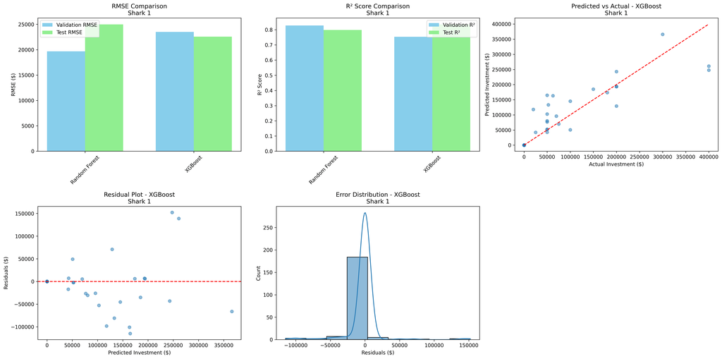

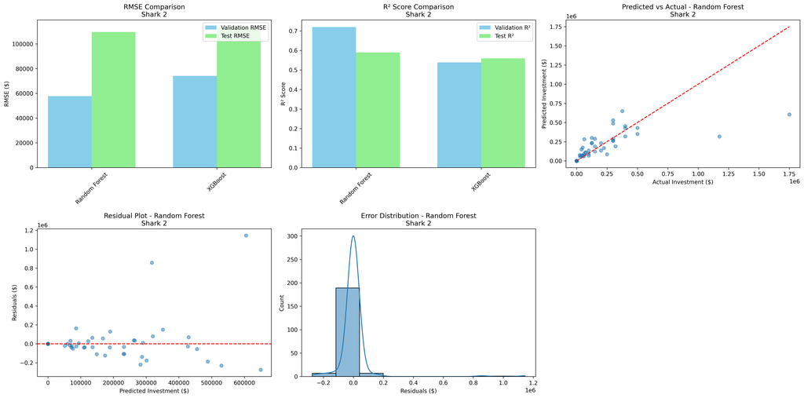

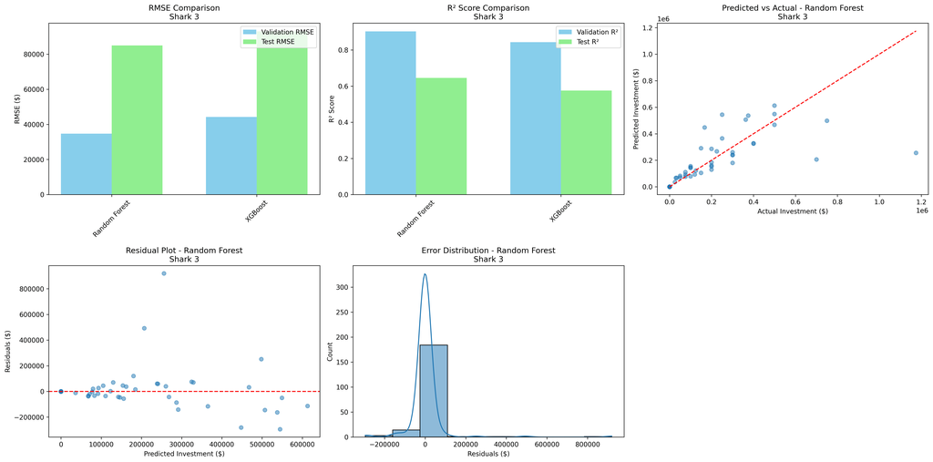

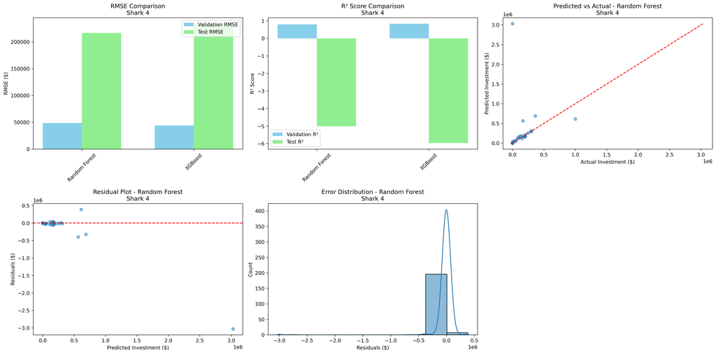

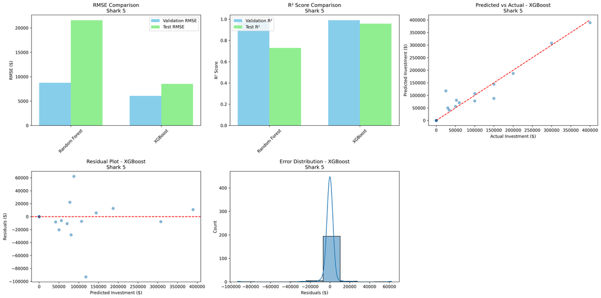

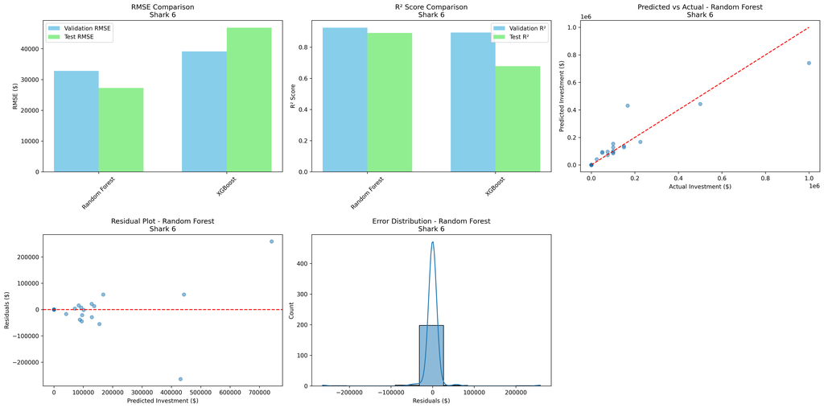

```python
with open('saved_regression_models/metadata.pkl', 'wb') as f:
    pickle.dump(all_regression_results, f)

def load_regression_models_and_predict(new_data):
    with open('saved_regression_models/scaler.pkl', 'rb') as f:
        saved_scaler = pickle.load(f)
    with open('saved_regression_models/metadata.pkl', 'rb') as f:
        saved_results = pickle.load(f)
    X_scaled = saved_scaler.transform(new_data)
    n_sharks = len(saved_results)
    predictions = np.zeros((len(new_data), n_sharks))
    for result in saved_results:
        shark_idx = result['shark_idx']
        with open(f'saved_regression_models/shark_{shark_idx+1}_regression_model.pkl', 'rb') as f:
            model = pickle.load(f)
        predictions[:, shark_idx] = model.predict(X_scaled)
    return predictions
```